# NLP: Word embeddings

```r
knitr::opts_chunk$set(echo = TRUE, cache = TRUE, collapse = TRUE)

# Initialize package
library(keras)
library(fs)
library(tidyverse)
library(glue)

# helper functions we'll use to explore word embeddings
source("helper_functions.R")
```

In this example, we are going to learn an about an alternative method to encode text data known as *word embeddings*. This is an incomplete tutorial on word embeddings but will at least give you the basic understanding on when and why we use them.

Learning objectives:

- What word embeddings are.
- The two main contexts that word embeddings are trained.
- When we should use word embeddings.
- How to train word embeddings for classification purposes.

# The “real” IMBD dataset

So far, we’ve been using the built-in IMBD dataset. Here, we are going to use the original data files which can be found at http://ai.stanford.edu/~amaas/data/sentiment/aclImdb_v1.tar.gz. We have already downloaded this data for you.

```r
imdb_dir <- here::here("docs", "data", "imdb")
fs::dir_tree(imdb_dir, type = "directory")
```

```
/Users/b294776/Desktop/Workspace/Training/rstudio-conf-2020/dl-keras-tf/docs/data/imdb
├── test
│   ├── neg
│   └── pos
└── train
    ├── neg
    └── pos
```

You can see the data have already been separated into test vs training sets and positive vs negative sets. The actual reviews are contained in individual .txt files. We can use this structure to our advantage - the below iterates over each review and

1. creates the path to each individual review file,
2. creats a label based on the “neg” or “pos” folder the review is in,
3. and saves the output as a data frame with each review on an individual row.

```r
training_files <- file.path(imdb_dir, "train") %>%
  dir_ls() %>%
  map(dir_ls) %>%
  set_names(basename) %>%
  plyr::ldply(data_frame) %>%
  set_names(c("label", "path"))

training_files
```

| label | path |
| --- | --- |
| neg | /Users/b294776/Desktop/Workspace/Training/rstudio-conf-2020/dl-keras-tf/docs/data/imdb/train/neg/0_3.txt |
| neg | /Users/b294776/Desktop/Workspace/Training/rstudio-conf-2020/dl-keras-tf/docs/data/imdb/train/neg/10000_4.txt |
| neg | /Users/b294776/Desktop/Workspace/Training/rstudio-conf-2020/dl-keras-tf/docs/data/imdb/train/neg/10001_4.txt |
| neg | /Users/b294776/Desktop/Workspace/Training/rstudio-conf-2020/dl-keras-tf/docs/data/imdb/train/neg/10002_1.txt |
| neg | /Users/b294776/Desktop/Workspace/Training/rstudio-conf-2020/dl-keras-tf/docs/data/imdb/train/neg/10003_1.txt |
| neg | /Users/b294776/Desktop/Workspace/Training/rstudio-conf-2020/dl-keras-tf/docs/data/imdb/train/neg/10004_3.txt |
| neg | /Users/b294776/Desktop/Workspace/Training/rstudio-conf-2020/dl-keras-tf/docs/data/imdb/train/neg/10005_3.txt |
| neg | /Users/b294776/Desktop/Workspace/Training/rstudio-conf-2020/dl-keras-tf/docs/data/imdb/train/neg/10006_4.txt |
| neg | /Users/b294776/Desktop/Workspace/Training/rstudio-conf-2020/dl-keras-tf/docs/data/imdb/train/neg/10007_1.txt |
| neg | /Users/b294776/Desktop/Workspace/Training/rstudio-conf-2020/dl-keras-tf/docs/data/imdb/train/neg/10008_2.txt |

[output cut: 990 more lines]

We can see our response observations are balanced:

```r
count(training_files, label)
```

| label | n |
| --- | --- |
| neg | 12500 |
| pos | 12500 |

We can now iterate over each row and

1. save the label in a label vector,
2. import the movie review and
3. save in a texts vector.

```r
obs <- nrow(training_files)
labels <- vector(mode = "integer", length = obs)
texts <- vector(mode = "character", length = obs)

for (file in seq_len(obs)) {
  label <- training_files[[file, "label"]]
  path <- training_files[[file, "path"]]

  labels[file] <- ifelse(label == "neg", 0, 1)
  texts[file] <- readChar(path, nchars = file.size(path))

}
```

We now have two vectors, one consisting of the labels and the other holding each review.

```r
table(labels)
```

```
labels
    0     1
12500 12500
```

```r
cat("\n")
```

```r
texts[1]
```

```
[1] "Story of a man who has unnatural feelings for a pig. Starts out with a opening scene that is a terrific example of absurd comedy. A formal orchestra audience is turned into an insane, violent mob by the crazy chantings of it's singers. Unfortunately it stays absurd the WHOLE time with no genera…
```

# Exploratory text analysis

A little exploratory analysis will show us the total number of unique words across our corpus and the average length of each review.

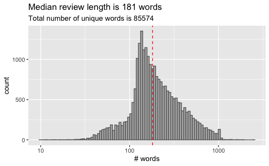

```r
text_df <- texts %>%
  tibble(.name_repair = ~ "text") %>%
  mutate(text_length = str_count(text, "\\w+"))

unique_words <- text_df %>%
  tidytext::unnest_tokens(word, text) %>%
  pull(word) %>%
  n_distinct()

avg_review_length <- median(text_df$text_length, na.rm = TRUE)

ggplot(text_df, aes(text_length)) +
  geom_histogram(bins = 100, fill = "grey70", color = "grey40") +
  geom_vline(xintercept = avg_review_length, color = "red", lty = "dashed") +
  scale_x_log10("# words") +
  ggtitle(glue("Median review length is {avg_review_length} words"),
          subtitle = glue("Total number of unique words is {unique_words}"))
```

# Word embeddings for language modeling

Word embeddings are designed to encode general semantic relationships which can serve two principle purposes. The first is for *language modeling* which aims to encode words for the purpose of predicting synonyms, sentence completion, and word relationships.

See slides for more discussion of this type of modeling. We are not focusing on word embeddings for this purpose; however, I have written a couple helper functions to train word embeddings for this purpose. See the code behind these helper functions [here](https://bit.ly/32HCP1G).

```r
# clean up text and compute word embeddings
clean_text <- tolower(texts) %>%
  str_replace_all(pattern = "[[:punct:] ]+", replacement = " ") %>%
  str_trim()

word_embeddings <- get_embeddings(clean_text)
```

```
Creating vocabulary...
Creating term-co-occurence matrix...
Computing embeddings based on GloVe algorithm...
```

```
INFO [2019-11-12 10:46:29] 2019-11-12 10:46:29 - epoch 1, expected cost 0.0819
INFO [2019-11-12 10:46:30] 2019-11-12 10:46:30 - epoch 2, expected cost 0.0557
INFO [2019-11-12 10:46:31] 2019-11-12 10:46:31 - epoch 3, expected cost 0.0487
INFO [2019-11-12 10:46:32] 2019-11-12 10:46:32 - epoch 4, expected cost 0.0445
INFO [2019-11-12 10:46:33] 2019-11-12 10:46:33 - epoch 5, expected cost 0.0416
INFO [2019-11-12 10:46:34] 2019-11-12 10:46:34 - epoch 6, expected cost 0.0396
INFO [2019-11-12 10:46:35] 2019-11-12 10:46:35 - epoch 7, expected cost 0.0380
INFO [2019-11-12 10:46:36] 2019-11-12 10:46:36 - epoch 8, expected cost 0.0368
INFO [2019-11-12 10:46:37] 2019-11-12 10:46:37 - epoch 9, expected cost 0.0358
INFO [2019-11-12 10:46:38] 2019-11-12 10:46:38 - epoch 10, expected cost 0.0349
INFO [2019-11-12 10:46:39] 2019-11-12 10:46:39 - epoch 11, expected cost 0.0342
INFO [2019-11-12 10:46:40] 2019-11-12 10:46:40 - epoch 12, expected cost 0.0336
INFO [2019-11-12 10:46:41] 2019-11-12 10:46:41 - epoch 13, expected cost 0.0331
INFO [2019-11-12 10:46:42] 2019-11-12 10:46:42 - epoch 14, expected cost 0.0326
INFO [2019-11-12 10:46:43] 2019-11-12 10:46:43 - epoch 15, expected cost 0.0322
INFO [2019-11-12 10:46:44] 2019-11-12 10:46:44 - epoch 16, expected cost 0.0318
INFO [2019-11-12 10:46:45] 2019-11-12 10:46:45 - epoch 17, expected cost 0.0315
INFO [2019-11-12 10:46:46] 2019-11-12 10:46:46 - epoch 18, expected cost 0.0312
INFO [2019-11-12 10:46:46] Success: early stopping. Improvement at iterartion 18 is less then convergence_tol
```

Explore your own words!

```r
# find words with similar embeddings
get_similar_words("horrible", word_embeddings)
```

```
 horrible  terrible     awful       bad    acting
1.0000000 0.9283386 0.9087303 0.8004550 0.7910296
```

# Word embeddings for classification

The other principle purpose for word embeddings is to encode text for classification reasons. In this case, we train the word embeddings to take on weights that optimize the classification loss function.

See slides for more discussion of this type of modeling.

## Prepare data

To prepare our data we need to convert or `labels` vector to a tensor:

```r
labels <- as.array(labels)
```

But more importantly, we need to preprocess our text features. To do so we:

1. Specify how many words we want to include. This will capture the 10,000 words with the highest usage (frequency).
2. Create a `text_tokenizer` object which defines how we want to preprocess the text (i.e. convert to lowercase, remove punctuation, token splitting characters). For the most part, the defaults are sufficient.
3. Apply the tokenizer to our text with `fit_text_tokenizer`. This results in an object with many details of our corpus (i.e. word counts, word index).

```r
top_n_words <- 10000

tokenizer <- text_tokenizer(num_words = top_n_words) %>%
  fit_text_tokenizer(texts)

names(tokenizer)
```

```
 [1] "char_level"                   "document_count"               "filters"
 [4] "fit_on_sequences"             "fit_on_texts"                 "get_config"
 [7] "index_docs"                   "index_word"                   "lower"
[10] "num_words"                    "oov_token"                    "sequences_to_matrix"
[13] "sequences_to_texts"           "sequences_to_texts_generator" "split"
[16] "texts_to_matrix"              "texts_to_sequences"           "texts_to_sequences_generator"
[19] "to_json"                      "word_counts"                  "word_docs"
[22] "word_index"
```

```r
total_word_index <- tokenizer$word_index
num_words_used <- tokenizer$num_words

glue("We have now tokenized our reviews. ", "We are considering {num_words_used} ",
     "of {length(total_word_index)} total unique words. The most common words ",
     "include:")
```

```
We have now tokenized our reviews. We are considering 10000 of 88582 total unique words. The most common words include:
```

```r
head(total_word_index)
```

```
$the
[1] 1

$and
[1] 2

$a
[1] 3

$of
[1] 4

$to
[1] 5

$is
[1] 6
```

Next, we extract our vectorized review data as a list. This looks familiar from the earlier modules.

```r
sequences <- texts_to_sequences(tokenizer, texts)

# The vectorized first instance:
sequences[[1]]
```

```
  [1]   62    4    3  129   34   44 7576 1414   15    3 4252  514   43   16    3  633  133   12    6    3 1301  459    4 1751
 [25]  209    3 7693  308    6  676   80   32 2137 1110 3008   31    1  929    4   42 5120  469    9 2665 1751    1  223   55
 [49]   16   54  828 1318  847  228    9   40   96  122 1484   57  145   36    1  996  141   27  676  122    1  411   59   94
 [73] 2278  303  772    5    3  837   20    3 1755  646   42  125   71   22  235  101   16   46   49  624   31  702   84  702
 [97]  378 3493    2 8422   67   27  107 3348
```

We can see how our tokenizer converted our original text to a cleaned up version:

```r
cat(crayon::blue("Original text:\n"))
```

```
Original text:
```

```r
texts[[1]]
```

```
[1] "Story of a man who has unnatural feelings for a pig. Starts out with a opening scene that is a terrific example of absurd comedy. A formal orchestra audience is turned into an insane, violent mob by the crazy chantings of it's singers. Unfortunately it stays absurd the WHOLE time with no genera…
```

```r
cat(crayon::blue("\nRevised text:\n"))
```

```
Revised text:
```

```r
paste(unlist(tokenizer$index_word)[sequences[[1]]] , collapse = " ")
```

```
[1] "story of a man who has unnatural feelings for a pig starts out with a opening scene that is a terrific example of absurd comedy a orchestra audience is turned into an insane violent mob by the crazy of it's singers unfortunately it stays absurd the whole time with no general narrative eventuall…
```

Next, since each review is a different length, we need to limit ourselves to a certain number of words so that all our features (reviews) are the same length.

Note (`?pad_sequences`): * Any reviews that are shorter than this length will be padded. * Any reviews that are longer than this length will be truncated.

```r
max_len <- 150
features <- pad_sequences(sequences, maxlen = max_len)
```

```r
features[1,]
```

```
  [1]    0    0    0    0    0    0    0    0    0    0    0    0    0    0    0    0    0    0    0    0
 [21]    0    0    0    0    0    0    0    0    0    0    0    0    0    0    0    0    0    0    0    0
 [41]    0    0    0    0    0    0   62    4    3  129   34   44 7576 1414   15    3 4252  514   43   16
 [61]    3  633  133   12    6    3 1301  459    4 1751  209    3 7693  308    6  676   80   32 2137 1110
 [81] 3008   31    1  929    4   42 5120  469    9 2665 1751    1  223   55   16   54  828 1318  847  228
[101]    9   40   96  122 1484   57  145   36    1  996  141   27  676  122    1  411   59   94 2278  303
[121]  772    5    3  837   20    3 1755  646   42  125   71   22  235  101   16   46   49  624   31  702
[141]   84  702  378 3493    2 8422   67   27  107 3348
```

```r
paste(unlist(tokenizer$index_word)[features[1,]], collapse = " ")
```

```
[1] "story of a man who has unnatural feelings for a pig starts out with a opening scene that is a terrific example of absurd comedy a orchestra audience is turned into an insane violent mob by the crazy of it's singers unfortunately it stays absurd the whole time with no general narrative eventuall…
```

### Your Turn!

Check out different reviews and see how we have transformed the data. Remove `eval=FALSE` to run.

```r
# use review number (i.e. 2, 10, 150)
which_review <- ____

cat(crayon::blue("Original text:\n"))
texts[[which_review ]]

cat(crayon::blue("\nRevised text:\n"))
paste(unlist(tokenizer$index_word)[features[which_review ,]] , collapse = " ")

cat(crayon::blue("\nEncoded text:\n"))
features[which_review ,]
```

Our data is now preprocessed! We have 25000 observations and 150 features.

```r
dim(features)
```

```
[1] 25000   150
```

```r
dim(labels)
```

```
[1] 25000
```

## Model training

```r
set.seed(123)
index <- sample(1:nrow(features))

x_train <- features[index, ]
y_train <- labels[index]
```

To create our network architecture that includes word embeddings, need to include two things:

1. `layer_embedding` layer that creates the embeddings,
2. `layer_flatten` to flatten our embeddings to a 2D tensor for our densely connected portion of our model

```r
model <- keras_model_sequential() %>%
  layer_embedding(
    input_dim = top_n_words,  # number of words we are considering
    input_length = max_len,   # length that we have set each review to
    output_dim = 8            # length of our word embeddings
    ) %>%
  layer_flatten() %>%
  layer_dense(units = 1, activation = "sigmoid")

summary(model)
```

```
Model: "sequential_3"
_________________________________________________________________________________________________________
Layer (type)                                   Output Shape                              Param #
=========================================================================================================
embedding_3 (Embedding)                        (None, 150, 8)                            80000
_________________________________________________________________________________________________________
flatten_3 (Flatten)                            (None, 1200)                              0
_________________________________________________________________________________________________________
dense_5 (Dense)                                (None, 1)                                 1201
=========================================================================================================
Total params: 81,201
Trainable params: 81,201
Non-trainable params: 0
_________________________________________________________________________________________________________
```

The rest of our modeling procedures follows the same protocols that you’ve seen in the other modules.

```r
model %>% compile(
  optimizer = "rmsprop",
  loss = "binary_crossentropy",
  metrics = c("acc")
)

history <- model %>% fit(
  x_train, y_train,
  epochs = 10,
  batch_size = 32,
  validation_split = 0.2
)
```

## YOUR TURN!

You may have noticed that we didn’t add any additional hidden layers to the densely connected portion of our model. Go ahead and add 1 or 2 more hidden layers. Also experiment with different word embedding dimensions (`output_dim`) and see if you can improve model performance.

```r
yourturn_model <- keras_model_sequential() %>%
  layer_embedding(
    input_dim = _____,
    input_length = _____,
    output_dim = _____
    ) %>%
  layer_flatten() %>%
  layer_dense(units = ____, activation = ____) %>%
  layer_dense(units = 1, activation = "sigmoid")

yourturn_model %>% compile(
  optimizer = "rmsprop",
  loss = "binary_crossentropy",
  metrics = c("acc")
)

yourturn_results <- yourturn_model %>% fit(
  x_train, y_train,
  epochs = 10,
  batch_size = 32,
  validation_split = 0.2
)
```

## Comparing embeddings

Recall that the word embeddings we found for natural language modeling created results like:

```r
# natural language modeling embeddings
get_similar_words("horrible", word_embeddings)
```

[output not shown]

However, embeddings we find for classification tasks are not always so clean and intuitive. We can get the word embeddings from our classification model with:

```r
wts <- get_weights(model)
embedding_wts <- wts[[1]]
```

The following just does some bookkeeping to extract the applicable words and assign them as row names to the embedding matrix.

```r
words <- tokenizer$word_index %>%
  as_tibble() %>%
  pivot_longer(everything(), names_to = "word", values_to = "id") %>%
  filter(id <= tokenizer$num_words) %>%
  arrange(id)

row.names(embedding_wts) <- words$word
```

The following is on of the custom functions you imported from the [helper_functions.R](https://bit.ly/32HCP1G) file. You can see the word embeddings that most closely align to a given word are not as intuitive as those produced from the natural language model. However, these are the embeddings that optimized for the classification procedure at hand.

```r
similar_classification_words("horrible", embedding_wts)
```

```
   horrible       feast        rips     reflect  sacrificed christopher
  1.0000000   0.9726146   0.9613024   0.9586546   0.9542472   0.9470869
```

Here’s a handy sequence of code that uses the [t-SNE](https://bit.ly/2rDk6rs) methodology to visualize nearest neighbor word embeddings.

```r
# plotting too many words make
n_words_to_plot <- 1000

tsne <- Rtsne::Rtsne(
  X = embedding_wts[1:n_words_to_plot,],
  perplexity = 100,
  pca = FALSE
  )

p <- tsne$Y %>%
  as.data.frame() %>%
  mutate(word = row.names(embedding_wts)[1:n_words_to_plot]) %>%
  ggplot(aes(x = V1, y = V2, label = word)) +
  geom_text(size = 3)

plotly::ggplotly(p)
```

[interactive chart not shown]